# Healthy Habits Workshop - Spring 2024 - Day 2: Software environments

# 1 Review of paper and get everyone caught up

For those of us who may not have been here on day 1, we’re going to be working on reproducing a paper that looked at evolution of E. coli transcription over the course of 22 years. We’re going to be going through this general workflow which runs from acquiring the raw data to cleaning the data, and then analyzing and finishing with visualization.

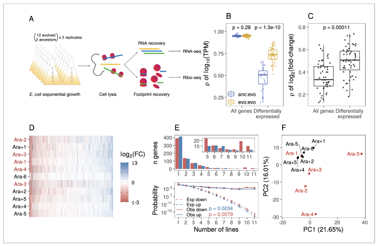

However, all ths scripts and some of the intermediate files will be provided for you so you can focus on the project management side and have the data analysis as a backdrop. To that end, to make sure we’re on the same page, let’s make sure we all have our project directory set up.

# 2 Setup

> 1. Log in to the cluster
> 2. Navigate to `/holyscratch01/<USERNAME>/`
> 3. Create a project directory and enter it:

```bash
mkdir healthy-habits
cd healthy-habits
```

> 4. Copy the project data to your directory:

```bash
cp /n/holylfs05/LABS/informatics/Everyone/workshop-data/healthy-habits-2024/day1/* .
```

> 5. Navigate to the project directory for this workshop that we created on Day 1:

```bash
cd healthy-habits/
```

> 6. Create sub-folders `software`, `data_raw`, and `scripts` and organize the project directory.
> 7. Create a project directory on your local computer and copy the files over using your preferred method

# 3 Software

This sets us up with the *data* we need for our project. However, to do any sort of analysis, we’ll need to use *software*. Software is any computer program that performs a function. A lot of software comes with any given computer, and a lot of it is necessary for the computer to run (e.g. the Operating System). For the most part though, any data analysis in any particular domain will require specialized software. For example, to analyze DNA sequences, you might use software like `samtools` or `bedtools`, which are not typically installed on a computer by default. That means a big chunk of analysis is reading about the available softare, deciding on what you need for your analysis, and then installing it.

## 3.1 Terminology

Before we get into the specifics of installing software, let’s go over some terminology. There are many different terms that are used to describe software, and it can be confusing. Here are some common ones:

| Term | Definition |
| --- | --- |
| Program | A specific set of ordered operations for a computer to perform. |
| Software | Any computer program that performs a function. |
| Script | A type of program written in a scripting language. |
| Application | A type of software that is designed to perform a specific set of tasks or activities for the user. |
| Package | A bundle of software and the metadata required to deploy it. |
| Library | A collection of pre-compiled pieces of code that can be reused in a program. Generally can’t be run on its own. |

You’ll notice that a lot of these definitions are very similar, and as such the terms are often used interchangeably. For example, you might hear someone refer to a program as a piece of software, or a script as a program. This is fine, but it can be confusing, so it’s helpful to know the different terms.

# 4 Dependencies

Software often bundles a lot of programs and libraries together. For example, the `samtools` software is actually a collection of programs that all work together to perform a specific task. This is called a *dependency*. Dependencies are other pieces of code that a given software needs to run. For example, `samtools` needs `htslib` to run. This is important because if you install `samtools` on your computer, you need to make sure that `htslib` is also installed. This can get complicated because `htslib` might need `zlib` to run, and `zlib` might need `libpng` to run, and so on. This is why software management is important.

These dependencies also need to be in a location that is findable by the main program. Typically, there are a few *environement variables* that tell the computer where to look for programs and their dependencies. One of these, on Unix systems, is `$PATH`.

> Type the following into your terminal:

```bash
echo $PATH
```

This will show you a list of directories that the computer looks in when you type a command. For example, if you type `samtools` into the terminal, the computer will look in each of these directories for a program called `samtools`. If it finds it, it will run it. If it doesn’t, it will tell you that it can’t find it, typically with a **command not found** error.

Similarly, when you install software, there are other directories that the computer looks in for dependencies.

Ok, well why does any of this matter when we want to install software?

# 5 File systems and permissions

We showed you this the other day:

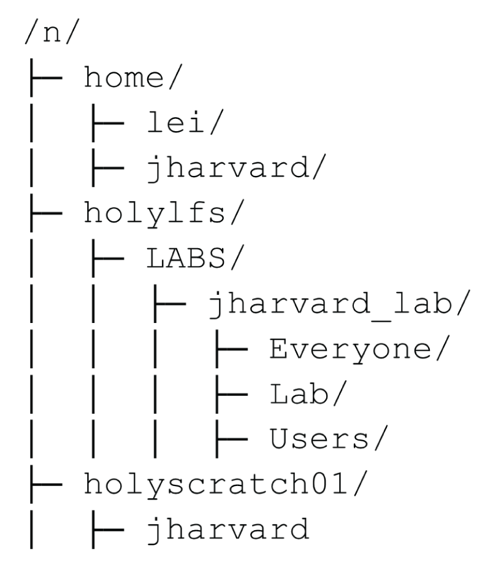

This show’s a cluster users typical view of the file system. The `home` directory is where you have a small amount of space for your personal files. The `holyscratch01` directory is where you have a large amount of space for temporary files. The `holylfs` is where each lab group has a large amount of space for their files. The directory where we have put the data for this workshop is in `holyscratch01/<USERNAME>/healthy-habits/`.

However, this is not the entire file system for the remote computer you’re operating on. Typically, the **ROOT** directory of a computer, that is the start of the file system, is `/` for Unix systems and `C:\` for Windows systems. The root directory contains all the files and directories on the computer, including the files and programs necessary for the computer to run. If we take a look at the root directory of any given login node on the cluster, it will look something like this:

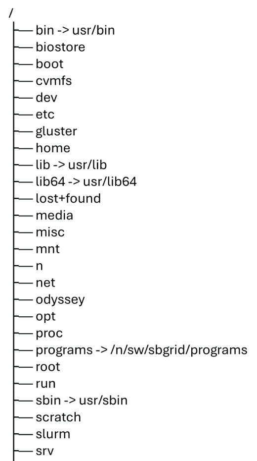

You almost never want to modify files or install software in the root directory because this can cause the computer to malfunction. Even experienced system administrators are careful about what they do in the root directory. Needless to say then, on a cluster with many users, the best practice is to make the root directory read-only.

However, most software is not developed on a cluster, so there are several assumptions that are commonly made when the writers of that software release it for others to install, key among them that the user will have full write permissions to the root directory of the computer that they are installing the software on. But this definitely isn’t the case.

> Type the following in your terminal:

```bash
ls -l /
```

This will show you the contents of the root directory and the permissions of each file and directory. The permissions are the first column of the output. They look like this:

```bash
drwxr-xr-x
```

This is a directory, and the permissions are `rwxr-xr-x`. The first three characters are the permissions for the owner of the file, the second three are the permissions for the group that the file belongs to, and the last three are the permissions for everyone else. The `r` stands for read, the `w` stands for write, and the `x` stands for execute. So, in this case, the owner of the file can read, write, and execute the file, and everyone else can only read and execute the file.

This means, that if we tried to manually install software on this computer, we would run into errors because we don’t have write permissions in these directories. There are ways around this, such as changing your path variables, setting the library directories when you’re installing the software, and installing all dependencies manually as well, but this is not recommonded because it’s a lot of work and it’s easy to make mistakes.

Instead, we’ll talk about two ways we can make software installation easier:

1. Containers
2. Environments

# 6 Containers

Containers are a way to package up software and all of its dependencies into a single file. This file can then be run on any computer that has the software that can run the container. This is a way to get around the permissions issue because the container is run in a way that doesn’t require write permissions to the root directory. There are a few different types of containers, but the two most popular are Docker and Singularity. Docker is the most popular, but Singularity is used on HPC systems (clusters) because it’s designed to be run on systems where the user doesn’t have write permissions to the root directory.

## 6.1 Singularity

Singularity images are typically stored as `.sif` files. These files can be run on any computer that has Singularity installed. Singularity is installed on the Cannon cluster, so we can use it to run our software. We can also use it to build our own containers, but we won’t be doing that today.

We’ve provided a Singularity image for the `sra-tools` program that we used to download the raw fastq files from the paper we’ll be working on. It should be in the `software` directory of the project directory and it is called `sra-tools-3.0.1.sif`.

> Type the following into your terminal (`fastq-dump` is one of the programs included with `sra-tools`). What happens?

```bash
fastq-dump -h
```

We do not have the `sra-tools` program installed on the cluster so we should see an error along the lines of **command not found**. However, we can use the sra-tools Singularity container to run the program.

There are two ways we can execute commands from a container.

1. The first is with `singularity exec <singularity image file> <command>`. This will run a whatever `<command>` you give it from the container and then exit. For instance, we can get the help menu for sra-tools.

> Type the following into your terminal:

```bash
singularity exec software/sra-tools-3.0.1.sif fastq-dump -h
```

Now we should see the full help menu for this program, and, if we wanted to, we could run the program from the Singularity container.

2. Another way we can run programs from a Singularity container is with `singularity shell <singularity image file>`. This will open a new shell that is running from the container. This is useful if we want to run a lot of commands from the container interactively, or if we want to run a program that requires a lot of input files.

> Type the following into your terminal:

```bash
singularity shell software/sra-tools-3.0.1.sif
```

You should see a new prompt in the terminal:

`Singularity>`

This is the prompt for the new shell that is running from the container. We can run any command that is in the container from this shell. For example, we can run the `fastq-dump` program.

> Type the following into your terminal:

```bash
fastq-dump -h
```

This should show you the help menu for the `fastq-dump` program. This is the same as the help menu we saw when we ran the program with `singularity exec`.

From within this shell, we can run any program that is installed in the container, even common Unix commands like `ls` work. However, any program that we have installed outside of the container (on the normal file system) will not be available from within the container.

Let’s exit our container shell.

> Type the following into your terminal:

```bash
exit
```

This will take you back to the normal shell.

## 6.2 BONUS: Converting Docker images to Singularity images

Docker is the most popular container system, and there are many more Docker images available than Singularity images. However, Docker images cannot be run on the Cannon cluster. But we can convert Docker images to Singularity images. This is a bit more complicated than just running a Singularity image, but it’s not too difficult.

1. Create an account on [the Singularity website](https://cloud.sylabs.io/) and login.
2. Generate an access token and copy it, or if you still have an active token just copy it.
3. On the cluster, run `singularity remote login` and paste the access token when prompted.
4. Run `singularity build <name of new singularity image file> docker://<docker image name>`. This will download the Docker image and convert it to a Singularity image.

Where can you find docker containers? Try searching quay.io; the biocontainers organization keeps many tools up to date there. For singularity containers, the galaxy project has an FTP server with many containers and can be found here: https://depot.galaxyproject.org/singularity/

# 7 Environments

While containers create a single file that contains an image of an operating system where the program you want to run is already installed, software environments essentially set-up folders on your computer and update your PATH variables so that you can run the software you want to run. This is a bit more complicated than running a container, but it’s also more flexible. For example, you can have multiple environments on your computer, and you can switch between them. This is useful if you’re working on multiple projects that require different versions of the same software. It’s also useful if you’re working on a project that requires a lot of software, because you can install all of the software you need in one environment and then switch to that environment when you want to work on that project.

# 8 conda and mamba

`conda` is a package manager that is used to install software environments. It is the most popular package manager for Python, but it can also be used to install software written in other languages. `mamba` is a faster version of `conda` that is also compatible with `conda` commands. We’ll be using `mamba` today.

`conda` and `mamba` are available on the Cannon cluster, however we still recommend installing them manually in a folder you have full control over (e.g. your home directory or your lab user directory).

## 8.1 A note on terminology

The term `conda` itself is used to refer to both the command line program for installing software and managing environments, and the software repository. The repository hosts software on various *channels*, such as `conda-forge`, which contains a lot of general purpose software, and `bioconda`, which contains a lot of bioinformatics software.

The term `mamba` is used only to refer to the command line program for installing software and managing environments. It is a drop-in replacement for `conda` and is compatible with `conda` commands.

## 8.2 Installing mamba

Today we’ll be installing `mamba` using [their recommended method of miniforge](https://mamba.readthedocs.io/en/latest/installation/mamba-installation.html), which is just the program pre-configured for a certain *channel*, `conda-forge`.

> 1. Type the following into your terminal:

```bash
wget https://github.com/conda-forge/miniforge/releases/latest/download/Miniforge3-Linux-x86_64.sh
```

This will download the miniforge installer to your current directory.

> 2. Type the following into your terminal:

```bash
bash Miniforge3-Linux-x86_64.sh
```

This will run the installer. You will be prompted to accept the license agreement, and then you will be prompted to choose an installation location. You can choose the default location, which is your home directory, or you can choose a different location.

> 3. Type the following into your terminal:

```bash
source ~/.bashrc
```

This will update your PATH variable so that you can run `mamba` from the terminal.

> 4. Type the following into your terminal:

```bash
mamba -h
```

This should show you the help menu for `mamba`. This means that `mamba` is installed and working.

You should also notice that your command prompt has changed. This is because the installer added a line to your `.bashrc` file that adds a string with your current environment prepended to the prompt.

It should now look something like this:

`(base) [username@login-node ~]$`

The `(base)` tells you that you’re in the `base` environment. This is the default environment that `mamba` creates when you install it.

NOTE: It is best practice to never install any software into the `base` environment. Instead, you should create a new environment for each project you work on, which we’ll cover below.

## 8.3 bioconda and setting up your channels

[bioconda](https://bioconda.github.io/) is a *channel* on the `conda` repository that contains a lot of bioinformatics software. It, along with the `conda-forge` channel, are likely to be the channels you’ll use almost exclusively.

> Navigate to the bioconda website: https://bioconda.github.io/

This website contains a lot of information about bioconda, including a list of all the software that is available on bioconda. Is there anything you notice on the front page that may be necessary for us?

> Set up your conda channels.

```bash
conda config --add channels defaults
conda config --add channels bioconda
conda config --add channels conda-forge
conda config --set channel_priority strict
```

This will add the `bioconda` and `conda-forge` channels to your conda configuration. This means that when you install software with `mamba`, it will look in these channels for the software you want to install. In most cases, you can also explicitly define the channel when you install software, however this is configuration is helpful for dependencies.

## 8.4 Creating an environment

Let’s get back to our goal for this workshop, which is to re-analyze some data in a paper ([Favate et al. 2022](https://doi.org/10.7554/eLife.81979)).

We’ve already downloaded the raw data and organized it into our project folder.

> If you’ve navigated away, navigate back to your project directory.

```bash
cd /holyscratch01/<USERNAME>/healthy-habits/
```

The first step in our analysis is to **remove the adapters** from the raw reads. To do this, we’ll use a program called `cutadapt`.

> Type the following into your terminal:

```bash
cutadapt -h
```

What happens?

We’ll need to install `cutadapt`, and we want to put it in an enviornment, so let’s create our first enviornment!

The typical syntax for creating an environment with `mamba` is `mamba create -n <environment name>`. The `-n` flag is used to specify the name of the environment. The environment name can be anything you want, but it’s helpful to give it a name that is descriptive of the project you’re working on.

> Type the following into your terminal:

```bash
mamba create -n cutadpt-env
```

If that finishes without error, we can confirm that the environment is created:

> Type the following into your terminal:

```bash
mamba env list
```

This just shows you a list of all the `mamba` environments you’ve created. You should see *cutadpt-env* in the list now.

## 8.5 Activating environments

You’ll notice that, even though we’ve created the environment, our command prompt still says `(base)`:

`(base) [username@login-node ~]$`

This is because we haven’t **activated** the environment yet. This is critical because:

1. You never want to install software into the `base` environment.
2. You want to be sure that you’re running the software from the environment you installed it in. Forgetting to activate the environment you want to be in can lead to a lot of confusion and errors.

To activate the environment, we use the `mamba activate` command.

> Type the following into your terminal:

```bash
mamba activate cutadpt-env
```

You should see your command prompt change to show that you’re in the `cutadpt-env` environment:

`(cutadpt-env) [username@login-node ~]$`

This means that any software you install will be installed into the `cutadpt-env` environment, and any software you run will be run from the `cutadpt-env` environment.

## 8.6 Installing software into environments

Ok, now we’re in the `cutadpt-env` environment!

> Type the following into your terminal:

```bash
cutadapt -h
```

Wait? Why are we still getting this error? Well, we may have created an environment that we intend to run `cutadapt` in, but we haven’t actually installed `cutadapt` into the environment yet.

To do that, let’s go to the [bioconda website](https://bioconda.github.io/) and search for `cutadapt`.

> 1. Search for `cutadapt` on the bioconda website.
> 2. Follow the instructions to install `cutadapt` into your `cutadpt-env` environment.

```bash
mamba install cutadapt
```

Be sure to say yes when it asks you if you want to install the software. Notice that, even though we only told it to install `cutadapt`, it also installed a lot of other software. This is because `cutadapt` has a lot of **dependencies**, and `mamba` automatically installs all of the dependencies for you.

This may take a minute or so (which is less time than if we used `conda`). Once it’s done, we can check to see if `cutadapt` is installed in the environment.

> Type the following into your terminal:

```bash
cutadapt -h
```

Finally! We should see the help menu for `cutadapt`. This means that `cutadapt` is installed in the `cutadpt-env` environment and we can run it from the environment.

## 8.7 Deactivating environments

If you want to leave an environment, perhaps to switch to another one, you can use the `mamba deactivate` command.

Let’s deactivate the cutadapt environment now.

> Type the following into your terminal:

```bash
mamba deactivate
```

You should see your command prompt change to show that you’re in the `base` environment:

`(base) [username@login-node ~]$`

This means that any software you install will be installed into the `base` environment (**don’t do this**), and any software you run will be run from the `base` environment. Any software that you had installed in your `cutadpt-env` environment will not be available from the `base` environment.